# RV預測project

### Part 5 : 時間序列模型

### AR & GARCH的rolling window forecasting

# 歡迎來到我們的RV預測Project第五集!!

### 我知道在Part 4最後，我們的模型確實表現比天真預測的baseline模型好，但是加入`IV加權`這個變數，並沒有增加模型的預能力。因此我們打算做一些`特徵工程`來將我們的輸入做些轉換。

深度學習被很多人喜愛的一個重點在於，其靈活的模型架構讓參數**可以去擬合出任何函數**，理論上這代表著即使是最**基本**的深度模型架構，都可以完成任何任務，故這讓深度學習有著**能夠自行找尋特徵**的能力。  
但實際上操作卻不是這麼一回事，輸入資料經過**特徵工程**轉換過後可以使模型的收斂更快速，預測表現更優秀。**學術界**在**深度學習對股價波動度預測**的主流架構都是將**輸入資料用傳統時間序列建模去估出參數，並作為模型的額外輸入資料**，以幫助模型訓練。  
我們也來試試吧！

### 金融時間序列有些不同於傳統時間序列的特性，如`不確定性、波動群聚`的現象。

從Part 3也觀察到波動群聚的現象，但那是籠統也視覺上的模式辨認。  
在時間序列處理時，有這以下的流程

1. 檢定時間序列是否是穩定的(stationary)，一般來說符合弱平穩(weak stationary)的時間序列就可以建模去做估計預測。非平穩的時間序列是不可能做建模的，故需進行些轉換。常用的檢定為ADF來檢定時間序列是否有單根的現象。
2. 若時間序列符合為穩定，我們可以用平均數模型去做建模，如AR、MA，以及上述的混合版ARMA等。建完模型並進行估計後，我們需要去觀察`殘差`的狀況，若`殘差`如同白噪音(white noise，本質上不可預測的市場衝擊、創新等)，那我們可以說我們的模型很好的捕捉了該時間序列的特性。
3. 然而金融時間序列再經過平均數模型的建模後，`殘差`多不會如同白噪音，也`殘差`的波動有明顯的聚集現象，意即高波動的區段會持續一段時間、低波動度段同理，故我們會再採用`ARCH、GARCH`等模型去捕捉`波動群聚的現象`。

## 1. 檢查我們的時間序列

我們會檢查我們的**log return**使否符合**平穩的時間序列**

```python
import numpy  as np
import pandas as pd
import sqlite3
```

```python
# 讀取database
db_path = '/Users/robert/Documents/碩士畢業論文/Code_and_db/RV_predict_project.db'
conn = sqlite3.connect(db_path, timeout = 20)
```

```python
# 讀取大盤的5秒日內資料
df = pd.read_sql_query("SELECT * FROM TAIEX_index_with_div ;", conn)
df
```

|  | 日期 | 時間 | 發行量加權股價指數 |
| --- | --- | --- | --- |
| 0 | 20160104 | 09:00:00 | 8338.06 |
| 1 | 20160104 | 09:00:05 | 8315.79 |
| 2 | 20160104 | 09:00:10 | 8312.26 |
| 3 | 20160104 | 09:00:15 | 8318.12 |
| 4 | 20160104 | 09:00:20 | 8316.53 |
| ... | ... | ... | ... |
| 5055955 | 20220525 | 13:29:40 | 18753.05 |
| 5055956 | 20220525 | 13:29:45 | 18753.05 |
| 5055957 | 20220525 | 13:29:50 | 18753.05 |
| 5055958 | 20220525 | 13:29:55 | 18753.05 |
| 5055959 | 20220525 | 13:30:00 | 18714.99 |

5055960 rows × 3 columns

```python
# 計算log return
# 找出2014/12/29後的每日收盤價
df_f = df[(df['時間']=='13:30:00') & (df['日期']<'20220525')]
df_f.reset_index(drop = True, inplace = True)

# 將'發行量加權股價指數'轉為float datatype，並計算log return
#df_f['發行量加權股價指數'] = df_f['發行量加權股價指數'].str.replace(',','').astype(float)
df_f['log_return'] = np.log(df_f['發行量加權股價指數']) - np.log(df_f['發行量加權股價指數'].shift(1))
```

```python
df_f = df_f[['日期','log_return']]
```

```python
df_f.dropna(inplace = True)
```

```python
# rescale
df_f['log_return'] = df_f['log_return'] * 100
df_f
```

|  | 日期 | log_return |
| --- | --- | --- |
| 1 | 20160105 | -0.483652 |
| 2 | 20160106 | -1.054692 |
| 3 | 20160107 | -1.746365 |
| 4 | 20160108 | 0.532326 |
| 5 | 20160111 | -1.346116 |
| ... | ... | ... |
| 1554 | 20220518 | 1.281617 |
| 1555 | 20220519 | -1.473430 |
| 1556 | 20220520 | 0.666195 |
| 1557 | 20220523 | 0.061618 |
| 1558 | 20220524 | -1.028471 |

1558 rows × 2 columns

```python
split_point = int(len(df_f) * 0.9)
train_df = df_f.iloc[1:split_point] #第一個為nan 故去除，之前LSTM直接以RV做處理，並沒有這樣的問題
train_df.reset_index(drop = True, inplace = True)
train_df
```

|  | 日期 | log_return |
| --- | --- | --- |
| 0 | 20160106 | -1.054692 |
| 1 | 20160107 | -1.746365 |
| 2 | 20160108 | 0.532326 |
| 3 | 20160111 | -1.346116 |
| 4 | 20160112 | -0.256736 |
| ... | ... | ... |
| 1396 | 20210923 | 0.781845 |
| 1397 | 20210924 | 0.928186 |
| 1398 | 20210927 | 0.270271 |
| 1399 | 20210928 | -0.668836 |
| 1400 | 20210929 | -1.665136 |

1401 rows × 2 columns

```python
test_df = df_f.iloc[split_point::]
test_df.reset_index(drop = True, inplace = True)
test_df
```

|  | 日期 | log_return |
| --- | --- | --- |
| 0 | 20210930 | 0.408222 |
| 1 | 20211001 | -1.885664 |
| 2 | 20211004 | -0.852702 |
| 3 | 20211005 | 0.277288 |
| 4 | 20211006 | -0.355802 |
| ... | ... | ... |
| 151 | 20220518 | 1.281617 |
| 152 | 20220519 | -1.473430 |
| 153 | 20220520 | 0.666195 |
| 154 | 20220523 | 0.061618 |
| 155 | 20220524 | -1.028471 |

156 rows × 2 columns

### 檢視時間序列的平穩性

```python
import statsmodels as sm
from statsmodels.tsa.stattools import acf, pacf
from statsmodels.tsa.arima.model import ARIMA
from arch import arch_model
import matplotlib.pyplot as plt
```

### 我們用Augmented Dickey-Fuller test來檢定這個time series是否有單根(unit root)的現象

H0: If failed to be rejected, it suggests the time series has a unit root, meaning it is non-stationary.  
Ha: The null hypothesis is rejected; it suggests the time series does not have a unit root, meaning it is stationary.

```python
result = sm.tsa.stattools.adfuller(train_df['log_return'])
print('ADF Statistic: %f' % result[0])
print('p-value: %f' % result[1])
```

```
ADF Statistic: -24.404920
p-value: 0.000000
```

### 很好，經過log轉換過後的每日return為平穩的時間序列。

在使用AR、MA等模型建模時，我們要選擇用lag幾期的模型，此時我們會檢視期acf跟pacf，說穿了就是檢定在t時點的資料跟過往t-1,t-2...t-n期的資料的**相關係數**，acf檢定相關係數，故t期跟t-n期的相關係數，除了t跟t-n的**直接影響**外，還會受到t-n期對t-n-1期等的影響，進而影響t的**間接影響**。而pacf為偏相關係數，只看t期跟t-n期的相關係數。

```
<BarContainer object of 20 artists>
```

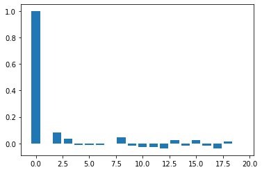

```python
acf_vals = acf(train_df['log_return'])
plt.bar(range(20), acf_vals[:20])
```

```
<BarContainer object of 20 artists>
```

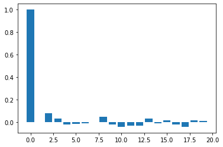

```python
pacf_vals = pacf(train_df['log_return'])
plt.bar(range(20), pacf_vals[:20])
```

## 看起來可以先試試lag 2期的模型，因爲lag 2期關聯性較明顯，但到lag 3期就開始減少

由於這個套件的forecast/predict都是用自己預測的值作為新的輸入，意即如果我要做第100期的預測，依照我們lag 2期的設計，會取前2期的資料作為模型的輸入去預測，但這前2期的預測並不是真的已經發生的資料，而是模型對98跟99期的預測值。  
這會使得在過長天期的預測逐漸趨近於平均值。

```python
model = ARIMA(train_df['log_return'], order=(2,0,2))
model_fit = model.fit()
print(model_fit.summary())
```

```
                               SARIMAX Results
==============================================================================
Dep. Variable:             log_return   No. Observations:                 1401
Model:                 ARIMA(2, 0, 2)   Log Likelihood               -1758.118
Date:                Tue, 12 Jul 2022   AIC                           3528.236
Time:                        21:59:37   BIC                           3559.706
Sample:                             0   HQIC                          3540.000
                               - 1401
Covariance Type:                  opg
==============================================================================
                 coef    std err          z      P>|z|      [0.025      0.975]
------------------------------------------------------------------------------
const          0.0624      0.025      2.535      0.011       0.014       0.111
ar.L1          0.8773      0.035     24.840      0.000       0.808       0.947
ar.L2         -0.8782      0.033    -26.265      0.000      -0.944      -0.813
ma.L1         -0.8723      0.030    -29.180      0.000      -0.931      -0.814
ma.L2          0.9240      0.027     33.845      0.000       0.871       0.978
sigma2         0.7202      0.014     50.252      0.000       0.692       0.748
===================================================================================
Ljung-Box (L1) (Q):                   0.20   Jarque-Bera (JB):              2546.34
Prob(Q):                              0.66   Prob(JB):                         0.00
Heteroskedasticity (H):               2.44   Skew:                            -0.71
Prob(H) (two-sided):                  0.00   Kurtosis:                         9.45
===================================================================================

Warnings:
[1] Covariance matrix calculated using the outer product of gradients (complex-step).
```

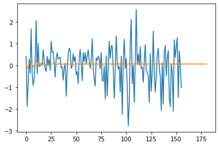

```python
pred = model_fit.forecast(181)
line1 = plt.plot(test_df['log_return'])
pred.reset_index(drop = True, inplace = True)
line2 = plt.plot(pred)
```

### 故我們改成 每預測完隔一天，就重新訓練模型，得到新的參數，並用新的資料去做預測。

```python
pred_list = []
for i in range(len(test_df)):
    model = ARIMA(df_f.loc[0 : (len(df_f) - len(test_df) + i), 'log_return'], order=(2,0,2))
    model_fit = model.fit()
    pred = model_fit.forecast()
    truth = df_f.loc[(len(df_f) - len(test_df) + i), 'log_return']
    print(f'prediction = {pred.iloc[0]}, truth = {truth}')
    data_tuple = tuple([truth, pred.iloc[0]])
    pred_list.append(data_tuple)
```

```python
truth_l = [i[0] for i in pred_list]
pred_l =  [i[1] for i in pred_list]
```

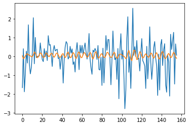

```python
line1 = plt.plot(truth_l)
line2 = plt.plot(pred_l)
```

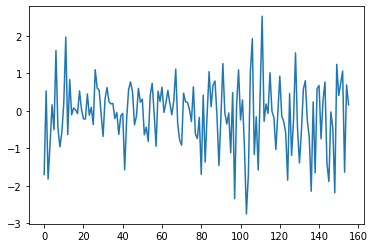

```python
residuel = np.array(truth_l) - np.array(pred_l)
plt.plot(residuel)
```

可以發現我們的**殘差項**看起來並不像**白噪音**，我們可以用**Ljung-box**去檢定。

Ho: 沒有auto correlation  
Ha: 有auto correlation

```python
import statsmodels.api as sm
```

```python
sm.stats.acorr_ljungbox(residuel, lags=[20], return_df=True)
```

|  | lb_stat | lb_pvalue |
| --- | --- | --- |
| 20 | 33.76237 | 0.027778 |

### 顯著拒絕虛無假說，代表我們的ARIMA並未完整捕捉到這個時間序列(台股每日log return)的訊號(signal)，我們可以做得更好。

**殘差項**有序列相關，是時候來使用GARCH模型來捕捉殘差的波動群聚現象。

```python
# 先重看一下我們的train & test set
train_df
```

|  | 日期 | log_return |
| --- | --- | --- |
| 0 | 20160106 | -1.054692 |
| 1 | 20160107 | -1.746365 |
| 2 | 20160108 | 0.532326 |
| 3 | 20160111 | -1.346116 |
| 4 | 20160112 | -0.256736 |
| ... | ... | ... |
| 1396 | 20210923 | 0.781845 |
| 1397 | 20210924 | 0.928186 |
| 1398 | 20210927 | 0.270271 |
| 1399 | 20210928 | -0.668836 |
| 1400 | 20210929 | -1.665136 |

1401 rows × 2 columns

```python
test_df.iloc[60::]
```

|  | 日期 | log_return |
| --- | --- | --- |
| 60 | 20211224 | 0.073008 |
| 61 | 20211227 | 0.424414 |
| 62 | 20211228 | 0.714795 |
| 63 | 20211229 | 0.247609 |
| 64 | 20211230 | -0.141553 |
| ... | ... | ... |
| 151 | 20220518 | 1.281617 |
| 152 | 20220519 | -1.473430 |
| 153 | 20220520 | 0.666195 |
| 154 | 20220523 | 0.061618 |
| 155 | 20220524 | -1.028471 |

96 rows × 2 columns

```python
model = arch_model(train_df['log_return'],mean='AR', lags = 1, vol="Garch", p=1, q=1)
```

```python
model_fit = model.fit()
print(model_fit.summary())
```

```
Iteration:      1,   Func. Count:      7,   Neg. LLF: 4763519022284.421
Iteration:      2,   Func. Count:     17,   Neg. LLF: 40663369447.32422
Iteration:      3,   Func. Count:     26,   Neg. LLF: 3493388920.943195
Iteration:      4,   Func. Count:     34,   Neg. LLF: 2200.984757741422
Iteration:      5,   Func. Count:     42,   Neg. LLF: 1690.5355376406635
Iteration:      6,   Func. Count:     49,   Neg. LLF: 1665.510326262756
Iteration:      7,   Func. Count:     57,   Neg. LLF: 1644.9396125893036
Iteration:      8,   Func. Count:     63,   Neg. LLF: 1644.924200748533
Iteration:      9,   Func. Count:     69,   Neg. LLF: 1644.9240223755214
Iteration:     10,   Func. Count:     75,   Neg. LLF: 1644.9240171607378
Iteration:     11,   Func. Count:     80,   Neg. LLF: 1644.9240171609872
Optimization terminated successfully    (Exit mode 0)
            Current function value: 1644.9240171607378
            Iterations: 11
            Function evaluations: 80
            Gradient evaluations: 11
                           AR - GARCH Model Results
==============================================================================
Dep. Variable:             log_return   R-squared:                      -0.001
Mean Model:                        AR   Adj. R-squared:                 -0.002
Vol Model:                      GARCH   Log-Likelihood:               -1644.92
Distribution:                  Normal   AIC:                           3299.85
Method:            Maximum Likelihood   BIC:                           3326.07
                                        No. Observations:                 1400
Date:                Tue, Jul 12 2022   Df Residuals:                     1398
Time:                        22:05:09   Df Model:                            2
                                   Mean Model
================================================================================
                    coef    std err          t      P>|t|       95.0% Conf. Int.
--------------------------------------------------------------------------------
Const             0.0899  2.109e-02      4.264  2.011e-05    [4.857e-02,  0.131]
log_return[1]    -0.0166  3.481e-02     -0.478      0.633 [-8.484e-02,5.159e-02]
                              Volatility Model
============================================================================
                 coef    std err          t      P>|t|      95.0% Conf. Int.
----------------------------------------------------------------------------
omega          0.0630  1.874e-02      3.361  7.755e-04 [2.626e-02,9.970e-02]
alpha[1]       0.1343  3.703e-02      3.626  2.876e-04   [6.170e-02,  0.207]
beta[1]        0.7786  3.919e-02     19.865  8.100e-88     [  0.702,  0.855]
============================================================================

Covariance estimator: robust
```

```python
model_fit.params['alpha[1]']
```

```
0.1342795236337562
```

```python
model_fit.params['beta[1]']
```

```
0.7785948585692744
```

```python
pred = model_fit.forecast(reindex = True)
```

```python
pred.variance
```

|  | h.1 |
| --- | --- |
| 0 | NaN |
| 1 | NaN |
| 2 | NaN |
| 3 | NaN |
| 4 | NaN |
| ... | ... |
| 1396 | NaN |
| 1397 | NaN |
| 1398 | NaN |
| 1399 | NaN |
| 1400 | 0.994294 |

1401 rows × 1 columns

```python
# 單純只做test set預測
rolling_predictions = []
for i in range(len(test_df)):

    train = df_f.loc[0:(len(train_df) + i), 'log_return'] **2
    model = arch_model(train, mean='AR', lags = 1, vol="Garch", p=1, q=1)
    model_fit = model.fit()
    pred = model_fit.forecast(horizon=1 , reindex = True)
    rolling_predictions.append(np.sqrt(pred.variance.values[-1,:][0] / 100))
```

## 由於GARCH最後預測出來的是`波動度`，故我們要拿原本的RV做比較

```python
RV_df = pd.read_sql_query("SELECT * FROM daily_RV", conn)
RV_df.head()
```

|  | 日期 | daily_RV |
| --- | --- | --- |
| 0 | 20160104 | 0.497078 |
| 1 | 20160105 | 0.524352 |
| 2 | 20160106 | 0.532219 |
| 3 | 20160107 | 0.508205 |
| 4 | 20160108 | 0.530575 |

```python
test_vol = RV_df['daily_RV'].iloc[-len(test_df):]
date =  RV_df['日期'].iloc[-len(test_df):]
```

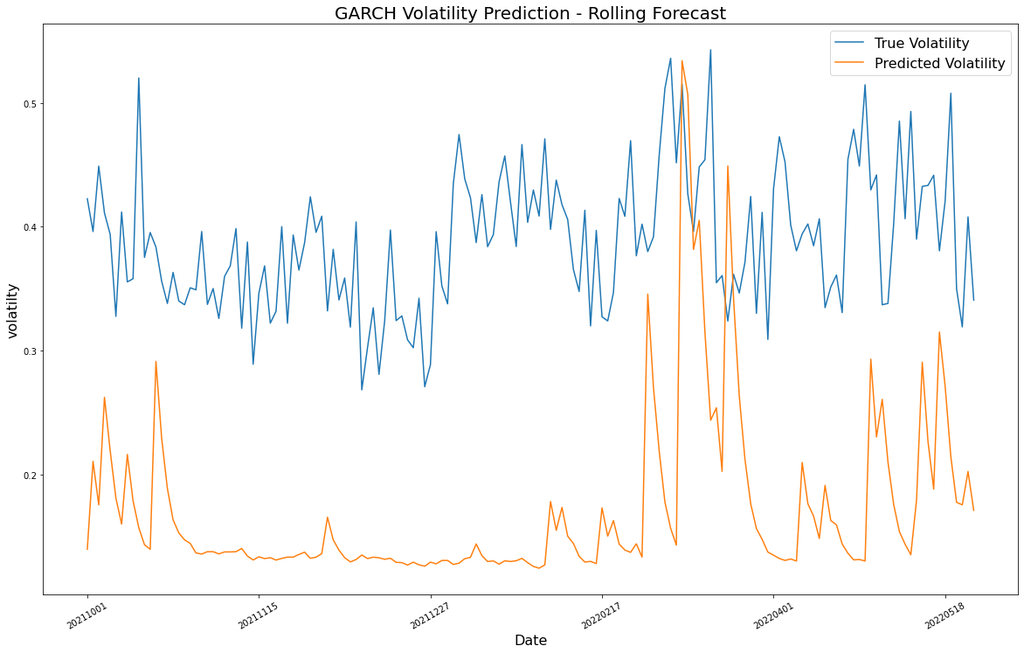

```python
test_vol = test_vol.reset_index(drop = True)

plt.figure(figsize=(20,12))
true =plt.plot(date, test_vol)
preds = plt.plot(date, rolling_predictions[-len(test_df):] )
plt.title('GARCH Volatility Prediction - Rolling Forecast', fontsize=20)
plt.xlabel('Date', fontsize=16)
plt.ylabel('volatilty', fontsize=16)
plt.xticks(np.arange(0, len(test_vol), step=30),fontsize = 10, rotation = 30) # x刻度 字的大小
plt.legend(['True Volatility', 'Predicted Volatility'], fontsize=16)
plt.savefig('/Users/robert/Documents/碩士畢業論文/figure_output/GARCH_prediction.png')
```

## GARCH突出的日子為2022年2月底，俄烏戰爭剛開始爆發的期間

```python
train = df_f.loc[0:4, 'log_return'] **2
model = arch_model(train, mean='AR', lags = 1, vol="Garch", p=1, q=1)
model_fit = model.fit()
pred = model_fit.forecast(horizon=1 , reindex = True)
rolling_predictions.append(np.sqrt(pred.variance.values[-1,:][0] / 100))
```

[output not shown]

接著我們將GARCH模型所估計的參數 結合原先的`RV`跟`IV`，來看看能不能提升模型預測的能力

```python
date_list = []
alpha = []
beta = []
rolling_predictions = []
for i in range(7, len(df_f) + 1): # 從7開始 因為我們LSTM的window為7
    # 這是只預測test set的做法，我們要連train set的資料一起做預測
    #train = df_f.loc[0:(len(train_df) + i), 'log_return'] **2
    train = df_f.loc[1:i, 'log_return'] **2
    model = arch_model(train, mean='AR', lags = 1, vol="Garch", p=1, q=1)
    model_fit = model.fit()
    pred = model_fit.forecast(horizon=1 , reindex = True)
    rolling_predictions.append(np.sqrt(pred.variance.values[-1,:][0] / 100))
    # 將該次GARCH的參數存至list中
    # 例如我們要預測5/20的波動度，我們train資料就只到5/19，我們的aplha跟beta也是5/19時點的估計值
    # 故
    date_list.append(df_f.loc[i, '日期'])
    alpha.append(model_fit.params['alpha[1]'])
    beta.append(model_fit.params['beta[1]'])
```

# 我們先將GARCH的參數估計值，跟`RV`&`IV`的表格的合併，並存在db的table中，在DataLoader就可以直接提取了

```python
# 先將GARCH的alpha跟beta與日期做表格的整理
GARCH_df = pd.DataFrame(date_list, columns = ['日期'])
```

```python
GARCH_df['alpha'] = alpha
GARCH_df['beta'] = beta
GARCH_df['GARCH_pred'] = rolling_predictions
```

```python
GARCH_df
```

|  | 日期 | alpha | beta | GARCH_pred |
| --- | --- | --- | --- | --- |
| 0 | 20160113 | 2.124761e-14 | 0.956246 | 0.083916 |
| 1 | 20160114 | 0.000000e+00 | 0.905072 | 0.062574 |
| 2 | 20160115 | 0.000000e+00 | 0.917466 | 0.064588 |
| 3 | 20160118 | 0.000000e+00 | 0.901012 | 0.057138 |
| 4 | 20160119 | 0.000000e+00 | 0.878440 | 0.047511 |
| ... | ... | ... | ... | ... |
| 1547 | 20220518 | 4.800182e-01 | 0.519982 | 0.175663 |
| 1548 | 20220519 | 4.795808e-01 | 0.520419 | 0.202544 |
| 1549 | 20220520 | 4.793009e-01 | 0.520699 | 0.171111 |
| 1550 | 20220523 | 4.793881e-01 | 0.520612 | 0.155085 |
| 1551 | 20220524 | 4.796582e-01 | 0.520342 | 0.145650 |

1552 rows × 4 columns

```python
# 將GARCH的參數跟IV RV做merge
db_path =  '/Users/robert/Documents/碩士畢業論文/Code_and_db/RV_predict_project.db'
conn = sqlite3.connect(db_path, timeout = 20)

''' 讀取RV資料、篩選日期'''
RV_data = pd.read_sql_query("SELECT * FROM Daily_RV", conn)
RV_data = RV_data[RV_data['日期'] <= '20220524']
RV_data.reset_index(drop = True, inplace = True)

''' 讀取IV資料，並將其與RV資料水平合併'''
IV_data = pd.read_sql_query("SELECT * FROM daily_IV", conn)
combine_df = RV_data.merge(IV_data, how='left', left_on='日期', right_on = '日期')
```

```python
combine_df
```

|  | 日期 | daily_RV | 大盤收盤價 | 距離到期日 | 無風險利率 | IV加權 |
| --- | --- | --- | --- | --- | --- | --- |
| 0 | 20160104 | 0.497078 | 8114.26 | 2 | 0.00235 | 0.153985 |
| 1 | 20160105 | 0.524352 | 8075.11 | 1 | 0.00232 | 0.150774 |
| 2 | 20160106 | 0.532219 | 7990.39 | 5 | 0.00232 | 0.163454 |
| 3 | 20160107 | 0.508205 | 7852.06 | 4 | 0.00232 | 0.172884 |
| 4 | 20160108 | 0.530575 | 7893.97 | 3 | 0.00232 | 0.192513 |
| ... | ... | ... | ... | ... | ... | ... |
| 1554 | 20220518 | 0.420785 | 16296.86 | 5 | 0.00180 | 0.127117 |
| 1555 | 20220519 | 0.507711 | 16020.32 | 4 | 0.00181 | 0.157531 |
| 1556 | 20220520 | 0.349904 | 16144.85 | 3 | 0.00182 | 0.186008 |
| 1557 | 20220523 | 0.319220 | 16156.41 | 2 | 0.00182 | 0.196686 |
| 1558 | 20220524 | 0.407964 | 15963.63 | 1 | 0.00180 | 0.181011 |

1559 rows × 6 columns

```python
combine_df = combine_df.merge(GARCH_df, how = 'inner', on = ['日期'])
```

```python
combine_df
```

|  | 日期 | daily_RV | 大盤收盤價 | 距離到期日 | 無風險利率 | IV加權 | alpha | beta | GARCH_pred |
| --- | --- | --- | --- | --- | --- | --- | --- | --- | --- |
| 0 | 20160113 | 0.516229 | 7824.61 | 5 | 0.00231 | 0.262317 | 2.124761e-14 | 0.956246 | 0.083916 |
| 1 | 20160114 | 0.607407 | 7742.88 | 4 | 0.00234 | 0.258390 | 0.000000e+00 | 0.905072 | 0.062574 |
| 2 | 20160115 | 0.612971 | 7762.01 | 3 | 0.00240 | 0.187411 | 0.000000e+00 | 0.917466 | 0.064588 |
| 3 | 20160118 | 0.668157 | 7811.18 | 2 | 0.00236 | 0.207791 | 0.000000e+00 | 0.901012 | 0.057138 |
| 4 | 20160119 | 0.530615 | 7854.88 | 1 | 0.00234 | 0.228108 | 0.000000e+00 | 0.878440 | 0.047511 |
| ... | ... | ... | ... | ... | ... | ... | ... | ... | ... |
| 1547 | 20220518 | 0.420785 | 16296.86 | 5 | 0.00180 | 0.127117 | 4.800182e-01 | 0.519982 | 0.175663 |
| 1548 | 20220519 | 0.507711 | 16020.32 | 4 | 0.00181 | 0.157531 | 4.795808e-01 | 0.520419 | 0.202544 |
| 1549 | 20220520 | 0.349904 | 16144.85 | 3 | 0.00182 | 0.186008 | 4.793009e-01 | 0.520699 | 0.171111 |
| 1550 | 20220523 | 0.319220 | 16156.41 | 2 | 0.00182 | 0.196686 | 4.793881e-01 | 0.520612 | 0.155085 |
| 1551 | 20220524 | 0.407964 | 15963.63 | 1 | 0.00180 | 0.181011 | 4.796582e-01 | 0.520342 | 0.145650 |

1552 rows × 9 columns

```python
combine_df.to_sql('IV_RV_GARCH_table',conn, index = False, if_exists = 'replace')
```

```
1552
```

```python
# 讀取看看
df = pd.read_sql_query("SELECT * FROM IV_RV_GARCH_table", conn)
df
```

|  | 日期 | daily_RV | 大盤收盤價 | 距離到期日 | 無風險利率 | IV加權 | alpha | beta | GARCH_pred |
| --- | --- | --- | --- | --- | --- | --- | --- | --- | --- |
| 0 | 20160113 | 0.516229 | 7824.61 | 5 | 0.00231 | 0.262317 | 2.124761e-14 | 0.956246 | 0.083916 |
| 1 | 20160114 | 0.607407 | 7742.88 | 4 | 0.00234 | 0.258390 | 0.000000e+00 | 0.905072 | 0.062574 |
| 2 | 20160115 | 0.612971 | 7762.01 | 3 | 0.00240 | 0.187411 | 0.000000e+00 | 0.917466 | 0.064588 |
| 3 | 20160118 | 0.668157 | 7811.18 | 2 | 0.00236 | 0.207791 | 0.000000e+00 | 0.901012 | 0.057138 |
| 4 | 20160119 | 0.530615 | 7854.88 | 1 | 0.00234 | 0.228108 | 0.000000e+00 | 0.878440 | 0.047511 |
| ... | ... | ... | ... | ... | ... | ... | ... | ... | ... |
| 1547 | 20220518 | 0.420785 | 16296.86 | 5 | 0.00180 | 0.127117 | 4.800182e-01 | 0.519982 | 0.175663 |
| 1548 | 20220519 | 0.507711 | 16020.32 | 4 | 0.00181 | 0.157531 | 4.795808e-01 | 0.520419 | 0.202544 |
| 1549 | 20220520 | 0.349904 | 16144.85 | 3 | 0.00182 | 0.186008 | 4.793009e-01 | 0.520699 | 0.171111 |
| 1550 | 20220523 | 0.319220 | 16156.41 | 2 | 0.00182 | 0.196686 | 4.793881e-01 | 0.520612 | 0.155085 |
| 1551 | 20220524 | 0.407964 | 15963.63 | 1 | 0.00180 | 0.181011 | 4.796582e-01 | 0.520342 | 0.145650 |

1552 rows × 9 columns

## 接下來採用GARCH參數丟去LSTM將會放在最後的Part 6，敬請期待！